# Introduction to the Command Line (Terminal) and the R Language Syntax

Gepoliano Chaves, Ph. D.

June 09, 2021

# 1) Basics of R

# 1.1) Basic Steps

- R can be accessed by clicking an icon or entering the command “R” at the system command line, also refered to as Terminal
- This produces a console window or causes R to start up as an interactive program at the current terminal window
- R works fundamentally by a question-and-answer model: enter a line with a command and press Enter
- Then the program does something relevant
- In this course, we will use RStudio and a file format called R Markdown, which allows us to code using not only R, but bash and Python, two other languages we may refer to as the course progresses

# 1.2) Library ISwR

- This Notebook was inspired in the book Introductory Statistics with R, by Peter Dalgaard
- For the book, R library ISwR (Introductory Statistics with R) can be freely downloaded
- All examples in the book used as reference should run provided that ISwR library is not only installed by also loaded into the current search path
- Library can be installed and loaded by typing the following command into an R chunk

```r
install.packages("ISwR")
library("ISwR")
```

- For a first impression of what R can do, let´s try plotting a graph

# 1.3) Plot Random Numbers

- Need to insert the R chunk and use the plot function

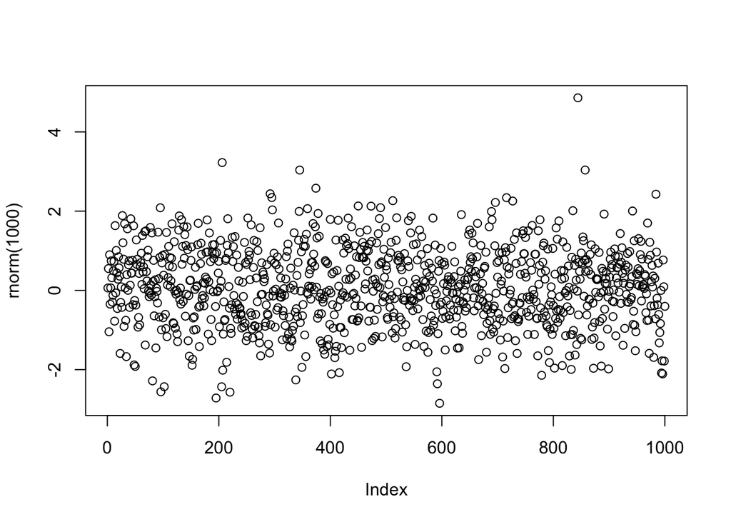

```r
plot(rnorm(1000))
```

# 1.4) A Potent Calculator

- R can process simple and complex arithmetic expression and produce a result for the user

```r
2 + 2
```

```
## [1] 4
```

- R can also be used to do other standard calculations. Here is how to calculate e to the power of -2

```r
exp(-2)
```

```
## [1] 0.1353353
```

- Other than the R chunks, these calculations can be made using the RStudio Console

# 1.5) Assignments

- Assignments made based on the necessity to store results of calculations and use these results in downstream processing steps in an entire pipeline
- Like other languages, R has symbolic variables: names that can be used to represent values
- To assign value 2 to variable x, one can enter

```r
x <- 2
```

- The character <- is called the assignment operator
- There is no immediate visible result, but from now on, x has the value 2 and can be used in subsequent arithmetic operations

# 1.6) Operations after Variable assignment

- Below, our variable x, is used to perform other calculations

```r
x
```

```
## [1] 2
```

```r
x + x ## Adition
```

```
## [1] 4
```

```r
5*x   ## Multiplication
```

```
## [1] 10
```

```r
x^3   ## Potentiation
```

```
## [1] 8
```

# 1.7) Vectorized Arithmetic

- It is not useful to use one number at a time to run statistics
- One strenght of R is that it can handle entire data vectors as single objects
- A data vector is an array of numbers and a vector variable can be constructed like this

```r
weight <- c(60, 72, 57, 90, 95, 72)

## To look at the vector variable, just type its name again
weight
```

```
## [1] 60 72 57 90 95 72
```

- You can do calculations with vectors just like ordinary numbers, so long as they have the same length
- One exception to this rule that we will see will be when we use the mean of weigths of persons (represented by xbar)
- In that case, the mean will be one single number, which will be subtracted from each sample value

# 1.7) Vectorized Arithmetic

- Suppose the weight vector indicates the weight of men in kilograms
- One simple formula to indicate whether a person is obese or not, is the body mass index (BMI)
- BMI is calculated by dividing the person´s weight by the square of their height, in meters
- Therefore, in R, we need to have a vector with the height values to calculate the bmi vector, containing the body-mass index for the individuals indicated in the weight vector

```r
height <- c(1.75, 1.80, 1.65, 1.90, 1.74, 1.91)
bmi <- weight/height^2
bmi
```

```
## [1] 19.59184 22.22222 20.93664 24.93075 31.37799 19.73630
```

# 1.8) Calculate the Mean of the variable weight

- The mean is calculated by the sum of the observations divided by the total number of observations

$\overline{x}$ = $\sum x_i$ /n

- Let´s calculate the mean of the variable weight

```r
sum(weight)
```

```
## [1] 446
```

```r
sum(weight)/length(weight)
```

```
## [1] 74.33333
```

# 1.9) Calculate the Standard-Deviation of the variable weight

- Standard-deviation can be calculated with the following equation

$$SD = \sqrt{(\sum (x_i - \overline{x})^2)/(n-1)}$$

- xbar, the mean of variable weight, can be calculated using the sum and length of variable weight

```r
xbar <- sum(weight)/length(weight)
xbar
```

```
## [1] 74.33333
```

- Now we can calculate the difference of each replicate in the weight variable and the mean of the weight variable, one by one

```r
weight - xbar
```

```
## [1] -14.333333  -2.333333 -17.333333  15.666667  20.666667  -2.333333
```

- Notice how R uses xbar, which has length one, to calculate the new weight - xbar data vector
- xbar is recycled and subracted from every element in the weight variable (weight data vector)

# 1.10) Calculation of the Standard Deviation

- Calculate the squared deviations

```r
(weight - xbar)^2
```

```
## [1] 205.444444   5.444444 300.444444 245.444444 427.111111   5.444444
```

- Calculate the sum of squared deviations

```r
sum((weight - xbar)^2)
```

```
## [1] 1189.333
```

- Calculate the standard deviation

```r
sqrt(
  sum(
    (weight - xbar)^2/
      (length(weight)-1)
)
)
```

```
## [1] 15.42293
```

# 1.11) Standard Statistical Procedures

- It is a standard medical practice to access whether a person is obese or not using validated scientific criteria
- As a simple procedure to show this concept, let’s assume that an individual with a normal weight should have a BMI in the range 20-25
- We want to know if our data deviates from the normal range of BMI
- In R, this can be done using a statistical test called t-test
- You do not need to understand what a t-test is, just remember that is is used to evaluate the distribution of sample values compared to the normal distribution
- You can use a one-sample t-test to assess whether the six persons’ BMI can be assumed to have mean 22.5 given that they come from a normal distribution
- You can do that using the function t.test

# 1.11) Standard Statistical Procedures: t-test

```r
t.test(
  bmi,
  mu = 22.5
)
```

```
##
##  One Sample t-test
##
## data:  bmi
## t = 0.34488, df = 5, p-value = 0.7442
## alternative hypothesis: true mean is not equal to 22.5
## 95 percent confidence interval:
##  18.41734 27.84791
## sample estimates:
## mean of x
##  23.13262
```

# 1.12) Plot Graphics

- Let’s now plot a scatterplot of the height and weight of individuals

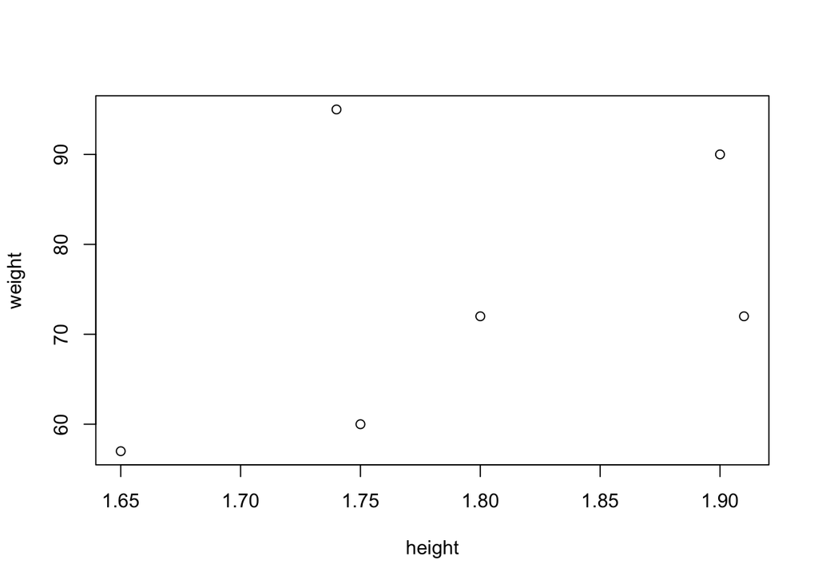

```r
plot(height, weight)
```